# Analysis of Film and Music Sales for Media Distributors, Inc.

Prepared by Oakland Partners

Shaobo Chen

Spring 2025 Semester

## 1 Background

Media Distributors, Inc. is a Wichita, KY based distributor and seller of films and music for commercial purposes. For the past few years, it has managed its film and music sales separately using different applications. This division is historical as Media Distributors started distributing films and then acquired SoundMania about two years ago. As the two distribution channels were different, CTO Alvin Coelho made the decision not to integrate the SoundMania’s information systems and database with those of Media Distributors. This has not been a problem until now, however Media Distributors intends to make itself available for acquisition. To that end, an integrated view of the business, particularly sales, is needed.

This report provides key sales, revenue, and customer metrics to showcase Media Distributors’ business. The analysis provided is based on data from a custom-built datamart that integrates data extracted from two operational databases.

## 2 Key Business Metrics

This section provides key revenue and customer information segmented by time, country, and business unit. Revenue numbers are in US$.

### 2.1 Sales Revenue

The year with the most sales was **2005** with a total revenue across both business units of **$66,902**. The country with the most sales was **Australia** with total sales across both business units in **2005** of **$33,647**. It was followed by **Canada** with **$33,255**.The table below shows sales revenue by country and ordered by total sales for the two most recent years, **2012** and **2013**. The table is restricted to the top five countries with the most sales. The column **‘Total’** in the table represents the total for all years for which there is data and not just the past two years.

Total Revenue For Top Five Countries For Most Recent Two Years

| Country | Revenue Per Year 2012 | Revenue Per Year 2013 | Total |
| --- | --- | --- | --- |
| Australia | $23 | $0 | $33,965 |
| Canada | $43 | $72 | $33,793 |
| USA | $128 | $85 | $523 |
| France | $37 | $41 | $195 |
| Brazil | $53 | $38 | $190 |

The table below shows the revenue broken down by quarter for the top five countries. It shows the total revenue for each quarter across all business units and years. So, for example, the column “Q1” is the total sales for music and film for all years for which there is data, which is from **2005** to **2013**.

Cumulative and Average Quarterly Revenue Quarterly Revenue 2005 to 2013

| Country | Q1 | Q2 | Q3 | Q4 | Average |
| --- | --- | --- | --- | --- | --- |
| Australia | 294 | 7,061 | 26,602 | 8 | 8,491 |
| Canada | 327 | 7,477 | 25,927 | 61 | 8,448 |
| USA | 97 | 136 | 163 | 128 | 131 |
| France | 60 | 46 | 42 | 48 | 49 |
| Brazil | 30 | 36 | 56 | 68 | 48 |

### 2.2 Customer Distribution

Across both business units, there are **658** customers **115** countries, with the majority of customers in **India**, **China**, and **United States**.

Customers by Business Unit

| Country | Film | Music | Total |
| --- | --- | --- | --- |
| India | 60 | 2 | 62 |
| China | 53 | 0 | 53 |
| United States | 36 | 0 | 36 |
| Brazil | 28 | 5 | 33 |
| Japan | 31 | 0 | 31 |

### 2.3 Film vs Music Revenue

Sales fluctuate over time and the table below shows total revenue per year for the years for which we have data.

Revenue by Year and Business Unit

| Business Unit | 2005 | 2006 | 2009 | 2010 | 2011 | 2012 | 2013 | Total |
| --- | --- | --- | --- | --- | --- | --- | --- | --- |
| film | 66,902 | 514 | 0 | 0 | 0 | 0 | 0 | 67,417 |
| music | 0 | 0 | 449 | 481 | 470 | 478 | 451 | 2,329 |

The graph below illustrates the quarterly growth of the film and music business over the past years for which we have data.

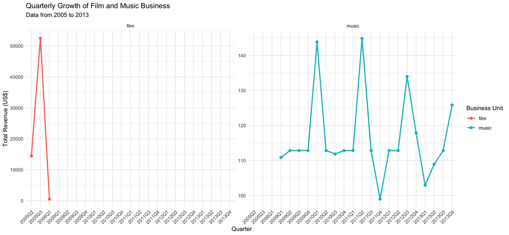

Number of units sold by country and business unit for past three years.

USA

Number of Units Sold by Quarter for USA

| Quarter | 2011 | 2012 | 2013 | Total | Average |
| --- | --- | --- | --- | --- | --- |
| Q1 | 12 | 18 | 14 | 44 | 15 |
| Q2 | 32 | 18 | 20 | 70 | 23 |
| Q3 | 29 | 38 | 20 | 87 | 29 |
| Q4 | 26 | 28 | 32 | 86 | 29 |
| Total | 99 | 102 | 86 | 287 | 96 |
| Average | 25 | 26 | 22 | 72 | 24 |

Canada

Number of Units Sold by Quarter for Canada

| Quarter | 2011 | 2012 | 2013 | Total | Average |
| --- | --- | --- | --- | --- | --- |
| Q1 | 26 | 10 | 20 | 56 | 19 |
| Q2 | 6 | 26 | 22 | 54 | 18 |
| Q3 | 9 | 2 | 25 | 36 | 12 |
| Q4 | 15 | 5 | 6 | 26 | 9 |
| Total | 56 | 43 | 73 | 172 | 57 |
| Average | 14 | 11 | 18 | 43 | 14 |

France

Number of Units Sold by Quarter for France

| Quarter | 2011 | 2012 | 2013 | Total | Average |
| --- | --- | --- | --- | --- | --- |
| Q1 | 10 | 9 | 20 | 39 | 13 |
| Q2 | 5 | 0 | 9 | 14 | 5 |
| Q3 | 18 | 5 | 9 | 32 | 11 |
| Q4 | 6 | 20 | 3 | 29 | 10 |
| Total | 39 | 34 | 41 | 114 | 38 |
| Average | 10 | 8 | 10 | 28 | 10 |

## 3 Summary and Recommendations

Despite these strengths, Media Distributors, Inc. faces challenges related to its siloed information systems. With plans for acquisition, the company must present a cohesive and integrated business view to appeal to potential buyers. With nearly **658** customers across **115** countries, Media Distributors should invest in customer relationship management (CRM) tools to personalize outreach and foster loyalty. Segmenting customers by preferences (film or music) and spending habits can optimize targeting.